# The Hidden Fiscal Costs of Climate

Dirk Heing & Charl Jooste

17/04/2020

## Study objective

How do climate events affect fiscal outcomes? Apart from setting away precautionary funds or disbursing when climate shocks materialize, many hidden costs are also present. Countries that face frequent and severe climate shocks might internalize a higher sovereign risk premium.

This risk premium is typically endogenous to the level of government debt, the health of the macroeconomic environment and general investor perceptions.

Below we decompose the implicit government interest rate into its fundamentals but now add climate events and climate vulnerabilities. This allows one to analyze amplification effects of fiscal costs that would have otherwise not be considered.

One may think of the channel as follows: Governments with weak institutions and large debt already have high risk premiums (i.e. investors require a large return because they price in country risk). If climate events trigger fiscal expansions under already stressed fiscal balances, then that might trigger a default, which should be accounted for in government interest rates.

Let’s start by defining the implicit interest rate as:

$$i_{i,t}=\frac{G^{Intp}_{i,t}}{D_{i,t}}$$
where $G^{Intp}_{i,t}$ is the government interest payments by country $i$ over period $t$, and $D$ is government gross debt.

We standardize each variable $(j)$ as:

$$X_{j,i,t}^{DM} =\frac{X_{j,i,t}-\bar{X}_{j,i,t}}{\sigma_j}$$

## Modeling interactions

Start by writing the implicit sovereign interest rate as a function of a mean and standard deviation:

$$i_{i,t} \sim N(u_{i,t},\sigma_i)$$
$$u_{i,t}=\alpha_i+\omega(VN_{i,t}-\bar{VN})+\theta \frac{D_{i,t}}{Y_{i,t}}$$
$$\omega=\gamma+\beta \frac{D_{i,t}}{Y_{i,t}}$$
This modeling setup assumed that interest rates follow a normal distribution, where the mean $(u_{i,t})$ contains country specific intercepts $(\alpha_i)$, fixed effects, is a function of the deviation of each country’s vulnerability $(VN)$ indicator from the world (which is averaged across countries and time) and a function of debt to GDP $(\frac{D_{i,t}}{Y_{i,t}})$. Interest rates are thus equal (in absense of high debt of climate shocks) equal to the country intercept.

If country vulnerability relative to the world increases (since investors differentiate between countries the deviation from the globe suggests that investors understand that there is an average level of disaster across the world) then interest rates should increase.

If we factor the model out we get an interaction term:

$$u_{i,t}=\alpha_i+\left(\gamma+\beta \frac{D_{i,t}}{Y_{i,t}}\right)(VN_{i,t}-\bar{VN})+\theta \frac{D_{i,t}}{Y_{i,t}}$$
$$u_{i,t}=\alpha_i+\gamma(VN_{i,t}-\bar{VN})+(\beta (VN_{i,t}-\bar{VN})+\theta) \frac{D_{i,t}}{Y_{i,t}}$$
In the absence of change in debt, the impact of vulnerabilities on interest rates is $\gamma$. With different levels of debt to GDP ratios, this gets applicied by $\gamma +\beta \theta \frac{D_{i,t}}{Y_{i,t}}$

## Data analysis

```
## 'data.frame':    4536 obs. of  29 variables:
##  $ Helper    : Factor w/ 4536 levels "ABW - 00","ABW - 01",..: 44 45 46 47 48 25 26 27 28 29 ...
##  $ COUNTRY   : Factor w/ 189 levels "ABW","AFG","AGO",..: 2 2 2 2 2 2 2 2 2 2 ...
##  $ YEAR      : int  1995 1996 1997 1998 1999 2000 2001 2002 2003 2004 ...
##  $ CRISCORE  : num  NA NA NA NA NA NA NA NA NA NA ...
##  $ DEBTCPIA  : num  NA NA NA NA NA NA NA NA NA NA ...
##  $ DRMCPIA   : num  NA NA NA NA NA NA NA NA NA NA ...
##  $ ENINTENS  : Factor w/ 2612 levels "1,067.85","100.00",..: NA NA NA NA NA NA NA NA NA NA ...
##  $ EXYFUEL   : num  NA NA NA NA NA NA NA NA NA NA ...
##  $ FATAL     : Factor w/ 246 levels "0.00","0.01",..: NA NA NA NA NA NA NA NA NA NA ...
##  $ FISCALCPIA: num  NA NA NA NA NA NA NA NA NA NA ...
##  $ GGDY      : num  NA NA NA NA NA ...
##  $ GOVEFFEC  : num  NA -2.18 -2.16 -2.14 -2.18 -2.23 -1.9 -1.57 -1.08 -0.89 ...
##  $ LOSSY     : num  NA NA NA NA NA NA NA NA NA NA ...
##  $ MACROCPIA : num  NA NA NA NA NA NA NA NA NA NA ...
##  $ NDVULN    : num  0.63 0.63 0.63 0.62 0.62 0.62 0.62 0.61 0.61 0.61 ...
##  $ PUBLICCPIA: num  NA NA NA NA NA NA NA NA NA NA ...
##  $ SMALL     : num  0 0 0 0 0 0 0 0 0 0 ...
##  $ SOVRATE   : num  NA NA NA NA NA NA NA NA NA NA ...
##  $ SWRESIL   : num  NA NA NA NA NA NA NA NA NA NA ...
##  $ SWRISKPHYS: num  NA NA NA NA NA NA NA NA NA NA ...
##  $ SWRISKWELL: num  NA NA NA NA NA NA NA NA NA NA ...
##  $ YCOAL     : num  NA NA NA NA NA NA NA 0 0.01 0.02 ...
##  $ YGAS      : num  NA NA NA NA NA NA NA 0.12 0.02 0.01 ...
##  $ YOIL      : num  NA NA NA NA NA NA NA 0.03 0.03 0.03 ...
##  $ YPC       : Factor w/ 4366 levels "1,001.09","1,015.82",..: NA NA NA NA NA NA NA 4 18 5 ...
##  $ YREV      : num  NA NA NA NA NA NA NA NA NA NA ...
##  $ YTAX      : num  NA NA NA NA NA NA NA NA NA NA ...
##  $ YGAP      : Factor w/ 1528 levels "-0.01","-0.02",..: NA NA NA NA NA NA NA NA 1148 87 ...
##  $ INTR      : Factor w/ 37 levels "-0.01","#N/A",..: NA NA NA NA NA NA NA NA 3 3 ...
```

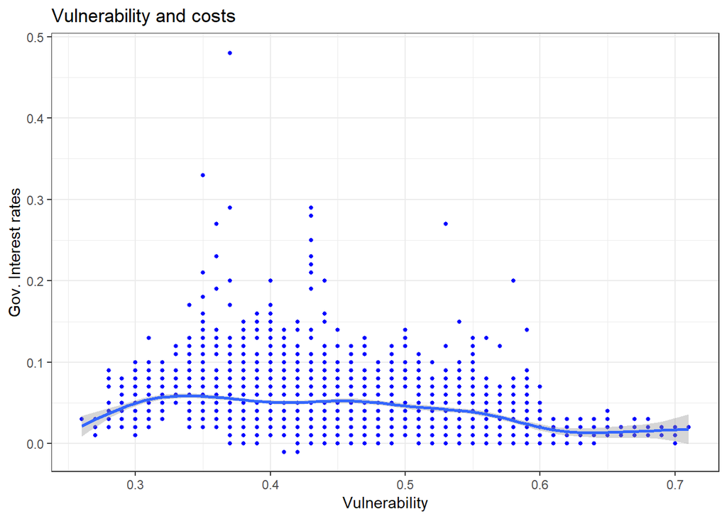

Vulnerabilities and interest rates

## Modeling results

For ranges of vulnerability $[0.35;0.54]$ and for different thresholds of debt $(>60 \%; 20 \%-40 \%; <20 \%;40 \%-60 \%)$ we are able to test how sensitive interest rates are to vulnerability and by how much this sensitivity gets amplified for a given debt to GDP ratio. The impact on interest rates is particularly strong for debt levels above $60\%$ interacting with high vulnerability.

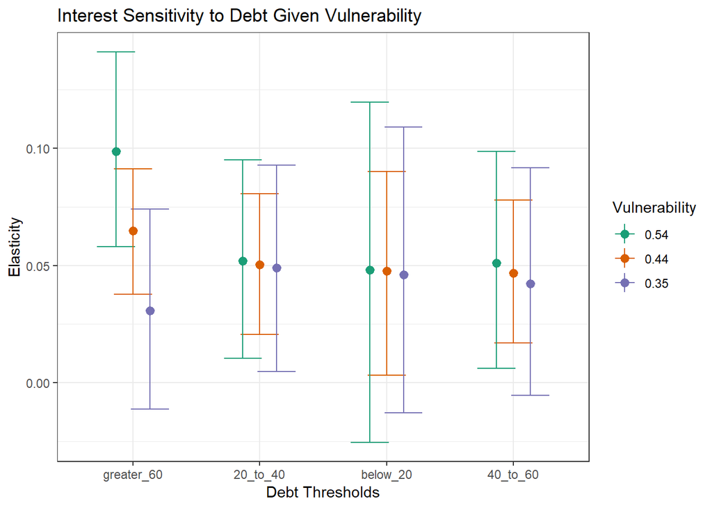

Elasticity - impact of vulnerability on interest rates

The impact of vulnerability on debt costs by itself (i.e. no interaction with other variables) is not particularly strong. The chart below is a posterior estimate of vulnerability $(\omega)$, where the median is slightly positive - while the median estimate is low, the ranges can be high if it interacts with debt:

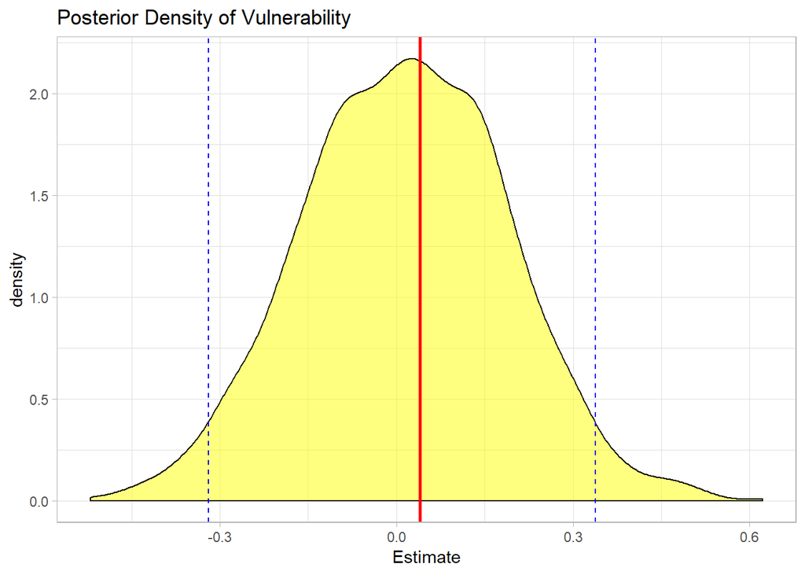

Posterior estimate of vulnerability on interest rates

Since the elasticities are functions of debt, they need to be evaluated as such too. This is represented as: